# Assignment V

Roßkopf Steffen

14.02.2021

# 1. Setting up a new GitHub repository

• Register on github.com in case you have not done this already.

• Initialize a new public repository for this assignment on GitHub.

• For the following exercises of this assignment, follow the standard Git workflow (i.e., pull the latest version of the project to your local computer, then stage, commit, and push all the modifications that you make throughout the project). Every logical programming step should be well documented on GitHub with a meaningful commit message, so that other people (e.g., your course instructor) can follow understand the development history. You can to do this either using Shell commands or a Git GUI of your choice.

• In the HTML file that you submit, include the hyperlink to the project repository

-> [here](https://github.com/rosskost/assignment_V) is the link to my repository

# 2. Getting to know the API

• Visit the documentation website for the API provided by ticketmaster.com (see [here](https://developer.ticketmaster.com/products-and-docs/apis/getting-started/)).

• Familiarize yourself with the features and functionalities of the Ticketmaster Discovery API. Have a particular look at rate limits.

• Whithin the scope of this assignment, you do not have to request your own API key. Instead retrieve a valid key from the API Explorer. This API key enables you to perform the GET requests needed throughout this assignment.

• Even though this API key is not secret per se (it is publicly visible onn the API Explorer website), please comply to the common secrecy practices discussed in the lecture and the tutorial: Treat the API key as a secret token. Your API key should neither appear in the code that you are submitting nor in your public GitHub repository.

```r
source("./key.R")
# users of this file, get your own api-key at:
# https://developer.ticketmaster.com/api-explorer/v2/
```

# 3. Interacting with the API - the basics

• Load the packages needed to interact with APIs using R.

• Perform a first GET request, that searches for event venues in Germany (countryCode = “DE”). Extract the content from the response object and inspect the resulting list. Describe what you can see.

```r
response_venues_de <- GET(url = "https://app.ticketmaster.com/discovery/v2/venues",
                           query = list(apikey = api_key,
                                        countryCode = 'DE',
                                        locale = '*'))

status_code(response_venues_de)  # status code = 200 -> succesful
```

```
## [1] 200
```

```r
#  json-content into R:
content_venues_de <- fromJSON(content(response_venues_de, as = "text"))

# the response list 'content_venues_de' consists of three main-lists. '_embedded', '_links'
# and 'page'. In _embedded.venues we find the relevant data we are looking for. Some of them
# are again a list. We recieved 20 observations.
# in '_links' we can find information on our search, on 'page' we can find information on which
# page we are on and how many more observations there are for our current request.
```

• Extract the name, the city, the postalCode and address, as well as the url and the longitude and latitude of the venues to a data frame.

```r
df_venues_de_small <- as.data.frame(list.flatten(content_venues_de)) %>%
  select(contains(
    c('venues.name','city.name','postalCode','address','venues.url','longitude','latitude'))) %>%
  set_colnames(c('name','city','postal_code','address','url','longitude','latitude')) %>%
  mutate("longitude" = as.numeric(longitude),
         "latitude" = as.numeric(latitude))

glimpse(df_venues_de_small)
```

```
## Rows: 20
## Columns: 7
## $ name        <chr> "Gruenspan", "Philharmonie (Großer Saal)", "Beatpol", "...
## $ city        <chr> "Hamburg", "Berlin", "Dresden", "Ludwigsburg", "Berlin"...
## $ postal_code <chr> "22767", "10785", "01157", "71638", "12435", "79108", "...
## $ address     <chr> "Grosse Freiheit 58", "Herbert-von-Karajan-Straße 1", "...
## $ url         <chr> "http://www.ticketmaster.de/venue/287155", "https://www...
## $ longitude   <dbl> 9.958075, 13.368960, 13.674710, 9.182400, 13.420540, 7....
## $ latitude    <dbl> 53.55188, 52.51007, 51.06498, 48.89121, 52.49945, 48.01...
```

# 4. Interacting with the API - advanced

• Have a closer look at the list element named page. Did your GET request from exercise 3 return all event locations in Germany? Obviously not - there are of course much more venues in Germany than those contained in this list. Your GET request only yielded the first results page containing the first 20 out of several thousands of venues.

• Check the API documentation under the section Venue Search. How can you request the venues from the remaining results pages?

```r
# there is a page-argument, which we can hand over as a key-value pair.
```

• Write a for loop that iterates through the results pages and performs a GET request for all venues in Germany. After each iteration, extract the seven variables name, city, postalCode, address, url, longitude, and latitude. Join the information in one large data frame.

```r
# doing that inside a function:

get_venues_of_country_ticketmaster <- function (country_code, api_key) {
  # idea: we make one initial get-request to get the number of elements and pages were looking
  # for, after that we use a loop to get all elements. This way this function is flexible for
  # all page sizes and number of observations


  initial_response <- GET(url = "https://app.ticketmaster.com/discovery/v2/venues",
                           query = list(apikey = api_key,
                                        countryCode = country_code,
                                        locale = '*',
                                        page = 0))

  initial_content <- fromJSON(content(initial_response, as = "text", encoding = "UTF-8"))

  dimensions_search <- unlist(initial_content[["page"]]) # here we find the
  # 'dimensions' of the request, we will do.

  size_page <- dimensions_search[1]
  n <- dimensions_search[2] # number of observations/rows in whole request
  number_pages <- dimensions_search[3]

  # setting up df, in which we store data in:
  df_venues_country <- data.frame(
    name = character(n),
    city = character(n),
    postal_code = character(n),
    address = character(n),
    url = character(n),
    longitude = character(n),
    latitude = character(n),
    stringsAsFactors = FALSE
  )

  Sys.sleep(0.2) # not really necessary, but waiting 0.2 after initial get-request

  # starting loop:
  for (page in 0:(number_pages-1)) { # pages zero indexed, so end at number_pages -1

    Sys.sleep(0.2) # after each page 0.2 seconds sleep, since only 5 requests per sec allowed

    if (page == (number_pages-1)) {  # if we are on the last page:

         response <- GET(url = "https://app.ticketmaster.com/discovery/v2/venues",
                           query = list(apikey = api_key,
                                        countryCode = country_code,
                                        locale = '*',
                                        page = page))

         content_parsed <- fromJSON(content(
           response, as = "text", encoding = "UTF-8"), flatten = TRUE)[["_embedded"]][["venues"]]

         names = list("name","city.name","postalCode","address.line1","url",
                       "location.longitude","location.latitude")
         i <- 0


         # this api's retruns are quite messy.
         # on some request, cols dont get returned, so need to account for
         # that and do each (20 row)-col seperately:
         for (column in names) {
           i <- i + 1
           if (column %in% colnames(content_parsed)) { # if column exists we
             df_venues_country[(page * size_page + 1):(n), i ] <- content_parsed %>%
               select(all_of(column))
           } else { # if column doesnt exist, we assine NA:
             df_venues_country[(page * size_page + 1):(n), i ] <- NA
           }
         }

    } else {  # we loop here whenever we arent on the last page
       response <- GET(url = "https://app.ticketmaster.com/discovery/v2/venues",
                           query = list(apikey = api_key,
                                        countryCode = country_code,
                                        locale = '*',
                                        page = page))
       content_parsed <- fromJSON(content(
         response, as = "text", encoding = "UTF-8"), flatten = TRUE)[["_embedded"]][["venues"]]

       names = list("name","city.name","postalCode","address.line1","url",
                       "location.longitude","location.latitude")
       i <- 0

       # on some request, cols dont get returned, so need to do each col seperately:
       for (column in names) {
         i <- i + 1
         if (column %in% colnames(content_parsed)) { # if col exists we assign it to correct col and row
           df_venues_country[(page * size_page + 1):((page+1)* size_page), i ] <- content_parsed %>%
             select(all_of(column))
         } else { # if column doesnt exist, we assine NA value
           df_venues_country[(page * size_page + 1):((page+1)* size_page), i ] <- NA
         }
       }
    }
  }
  # at the end return the final df
  return(df_venues_country %>%
           mutate("longitude" = as.numeric(longitude),
                  "latitude" = as.numeric(latitude)))
}
```

```r
# nowmcalling this function to get the df for germany

df_venues_de_full = get_venues_of_country_ticketmaster(country_code = "DE", api_key)
# takes around 3 1/2 min, which is appropiate respecting  the api providers limitations.
```

• The resulting data frame should look something like this (note that the exact number of search results may have changed since this document has been last modified):

```r
glimpse(df_venues_de_full)
```

```
## Rows: 12,238
## Columns: 7
## $ name        <chr> "Gruenspan", "Philharmonie (Großer Saal)", "Beatpol", "...
## $ city        <chr> "Hamburg", "Berlin", "Dresden", "Ludwigsburg", "Berlin"...
## $ postal_code <chr> "22767", "10785", "01157", "71638", "12435", "79108", "...
## $ address     <chr> "Grosse Freiheit 58", "Herbert-von-Karajan-Straße 1", "...
## $ url         <chr> "http://www.ticketmaster.de/venue/287155", "https://www...
## $ longitude   <dbl> 9.958075, 13.368960, 13.674710, 9.182400, 13.420540, 7....
## $ latitude    <dbl> 53.55188, 52.51007, 51.06498, 48.89121, 52.49945, 48.01...
```

# 5. Visualizing the extracted data

• Below, you can find code that produces a map of Germany. Add points to the map indicating the locations of the event venues across Germany.

• You will find that some coordinates lie way beyond the German borders and can be assumed to be faulty. Set coordinate values to NA where the value of longitude is outside the range (5.866944, 15.043611) or where the value of latitude is outside the range (47.271679, 55.0846) (these coordinate ranges have been derived from the extreme points of Germany as listed on Wikipedia (see here). For extreme points of other countries, see here).

```r
# we will set all lat and long values who are not in this range to NA:

df_venues_de_full$longitude[df_venues_de_full$longitude < 5.866944 | df_venues_de_full$longitude > 15.043611] <- NA

df_venues_de_full$latitude[df_venues_de_full$latitude < 47.271679 | df_venues_de_full$latitude > 55.0846] <- NA
```

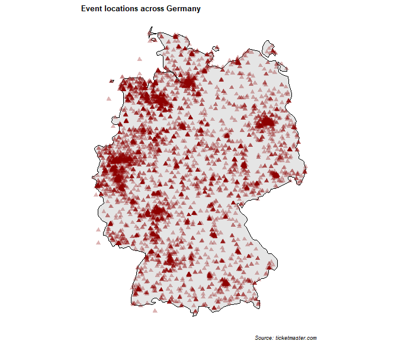

```r
ggplot() +
  geom_polygon(
    aes(x = long, y = lat, group = group), data = map_data("world", region = "Germany"),
    fill = "grey90",color = "black") +
  theme_void() +
  coord_quickmap() +
  # to plot we just add this geom_point layer:
  geom_point(data = df_venues_de_full, aes( x = longitude, y = latitude),
             color = "red4", shape = 17, size = 2, alpha = 0.3) +
  labs(title = "Event locations across Germany", caption = "Source: ticketmaster.com") +
  theme(title = element_text(size=8, face='bold'),
        plot.caption = element_text(face = "italic"))
```

# 6. Event locations in other countries

• Repeat exercises 2 to 5 for another European country of your choice. (Hint: Clean code pays off! If you have coded the exercises efficiently, only very few adaptions need to be made.)

```r
# using osterreich: exercise 2, first GET-request

response_venues_at <- GET(url = "https://app.ticketmaster.com/discovery/v2/venues",
                           query = list(apikey = api_key,
                                        countryCode = 'AT',
                                        locale = '*',
                                        page = 0))

status_code(response_venues_at)  # succesful
```

```
## [1] 200
```

```r
content_venues_at <- fromJSON(content(response_venues_at, as = "text"))

# exact same return structure as in DE-case.
# On page we see that we will now have 350 observations in total.
```

```r
df_venues_at_small <- as.data.frame(list.flatten(content_venues_at)) %>%
  select(contains(
    c('venues.name','city.name','postalCode','address','venues.url','longitude','latitude'))) %>%
  set_colnames(c('name','city','postal_code','address','url','longitude','latitude')) %>%
  mutate("longitude" = as.numeric(longitude),
         "latitude" = as.numeric(latitude))


glimpse(df_venues_at_small)
```

```
## Rows: 20
## Columns: 7
## $ name        <chr> "Grelle Forelle", "Stadthalle Graz", "Ottakringer Braue...
## $ city        <chr> "Vienna", "Graz", "Vienna", "Vienna", "Spital am Semmer...
## $ postal_code <chr> "1090", "8010", "1160", "1030", "8684", "1150", "1150",...
## $ address     <chr> "Spittelauer Lände 12", "Messeplatz 1", "Ottakringer Pl...
## $ url         <chr> "https://www.ticketmaster.at/venue/grelle-forelle-wien-...
## $ longitude   <dbl> 16.36100, 15.44689, 16.32457, 16.40542, 15.76987, 16.33...
## $ latitude    <dbl> 48.23425, 47.05797, 48.21249, 48.18735, 47.60456, 48.20...
```

```r
# now using the function we have minimal work to do:

df_venues_at = get_venues_of_country_ticketmaster(country_code = "AT", api_key)

glimpse(df_venues_at)
```

```
## Rows: 350
## Columns: 7
## $ name        <chr> "Grelle Forelle", "Stadthalle Graz", "Ottakringer Braue...
## $ city        <chr> "Vienna", "Graz", "Vienna", "Vienna", "Spital am Semmer...
## $ postal_code <chr> "1090", "8010", "1160", "1030", "8684", "1150", "1150",...
## $ address     <chr> "Spittelauer Lände 12", "Messeplatz 1", "Ottakringer Pl...
## $ url         <chr> "https://www.ticketmaster.at/venue/grelle-forelle-wien-...
## $ longitude   <dbl> 16.36100, 15.44689, 16.32457, 16.40542, 15.76987, 16.33...
## $ latitude    <dbl> 48.23425, 47.05797, 48.21249, 48.18735, 47.60456, 48.20...
```

Ploting as last task:

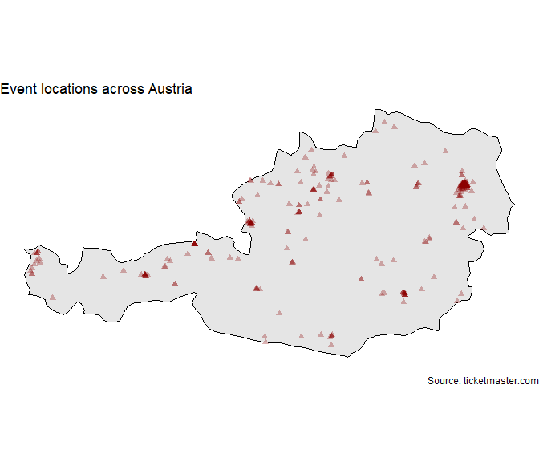

```r
ggplot() +
  geom_polygon(
    aes(x = long, y = lat, group = group), data = map_data("world", region = "Austria"),
    fill = "grey90",color = "black") +
  coord_quickmap() +
  geom_point(data = df_venues_at %>%
               filter(latitude < 49 & latitude > 45), # filter out three extreme points
             aes( x = longitude, y = latitude), color="red4", shape=17, size=2, alpha=.3) +
  labs(title = "Event locations across Austria", caption = "Source: ticketmaster.com") +
  theme(title = element_text(size=8, face='bold'),
        plot.caption = element_text(face = "italic")) +
  theme_void()
```